# GSUA-CSB Toolbox — user guide

Global Sensitivity and Uncertainty Analysis — Confidence Subcontour Box (GSUA-CSB) is a command-line toolbox, developed at Universidad EAFIT, for validating mathematical models built in Simulink, with the Symbolic Math Toolbox, or as plain MATLAB functions. It performs variance-based sensitivity analysis (SA) and uncertainty analysis (UA), estimates model parameters (PE), analyzes their practical identifiability, and estimates confidence subcontour boxes (CSB) for the estimates. It builds on the earlier work of Carlos Mario Vélez, GSUA of dynamical systems using variance-based methods.

Developers: Daniel Rojas Díaz (drojasd@eafit.edu.co) · Carlos Mario Vélez Sánchez (cmvelez@eafit.edu.co).

How this guide is organized. It opens with the one function every workflow starts from — gsua_dataprep, which turns a model into the summary table T — and then walks the pipeline: simulate, sample, UA, SA, estimate, analyze identifiability, and size confidence intervals. Each function has its own section with its purpose, its call syntax, and a complete list of its name–value arguments with defaults. The three model-preparation workflows (Simulink, symbolic, user-defined) are detailed in the appendix.

Every function also has standard help: type help gsua_dmatrix (or any function name) at the command line for the same reference, and open gsua_userguide to reopen this guide.

Contents

0. Preparing a model — gsua_dataprep 1. Simulate the model — gsua_eval 2. Sample the factor space — gsua_dmatrix 3. Uncertainty analysis — gsua_ua 4. Sensitivity analysis — gsua_sa 5. Parameter estimation — gsua_pe 5.1 Practical identifiability — gsua_ia and gsua_dia 5.2 Parametric bootstrap of parameter uncertainty — gsua_bootstrap 6. Uncertainty-interval calculus — gsua_oatr and gsua_csb 7. Fit quality, acceptance, and confidence intervals 7.1 Band coverage and tightness — gsua_covmetric 7.2 Which runs to keep — gsua_costcutoff 7.3 A data-calibrated acceptance threshold — gsua_noisefloor 7.4 Profile-likelihood confidence intervals — gsua_likelihood 8. Supporting functions 9. Python port Appendix A — Simulink models Appendix B — Symbolic ODE models Appendix C — User-defined functions

## 0. Preparing a model — gsua_dataprep

gsua_dataprep is the entry point: it consolidates a model and its factor ranges into the summary table T that every other function consumes. It dispatches on the first argument, so the call differs by model kind:

- Simulink model — [T,tout] = gsua_dataprep(model_name, Ranges, Parameter_names)
- Symbolic ODE system — [T,solver] = gsua_dataprep(odes, vars, domain, model_name)
- User-defined function — [T,solver] = gsua_dataprep(func, Ranges, 'domain', domain)

A factor is any input, parameter, or initial condition under analysis. Ranges is an Np x 2 array of [lower upper] bounds, one row per factor; give a factor a degenerate range (lower == upper) to fix it — fixed factors drop out of T. The appendix shows each workflow end to end, including the name–value arguments specific to each kind ('rMethod', 'nominal', 'output', 'names', 'out_names', 'solver', 'opt', 'vectorized', 'modelkind', 'Step').

For the worked examples below we use the bundled symbolic model, loaded with:

```matlab
default_example;
```

Setting environment to work with symbolic Matlab Introduce ranges in the following order:

ans =

```matlab
T
```

T = 4×2 table

|  | Range 1 | Range 2 | Nominal |  |
| --- | --- | --- | --- | --- |
| 1 S0 | 100 | 3000 |  | 1550 |
| 2 I0 | 1 | 500 | 250.5000 |  |
| 3 beta | 0 | 1 | 0.5000 |  |
| 4 gamma | 0 | 1 | 0.5000 |  |

## 1. Simulate the model — gsua_eval

gsua_eval runs the model for one or a few factor vectors and returns the output, interpolated onto xdata when given. It is the quickest way to check that a freshly prepared T actually simulates, and to overlay candidate factor families against data. For many simulations (Monte-Carlo sweeps) use gsua_pardeval instead.

Call syntax: [y,xdata] = gsua_eval(values, Table, xdata, ydata, parallel, show, verbose). values is Np x N (factors by simulations); the trailing arguments are positional, not name–value:

- xdata (default []) — time points to interpolate the output onto. Empty uses the model's own domain grid.
- ydata (default []) — reference/experimental data drawn alongside the model output for comparison.
- parallel (default false) — evaluate the columns of values in parallel.
- show (default true) — draw the result with gsua_plot; pass false to suppress the figure.
- verbose (default true) — print the Progress: N % line; pass false for a quiet run.

```matlab
% A single simulation at the nominal factor values stored in T.Nominal:
y = gsua_eval(T.Nominal, T, [], [], false, false, false);
% Build a noisy synthetic dataset to reuse in later sections:
xdata = linspace(0, 264, 265);
yclean = gsua_eval([1000 200 0.1 0.06]', T, xdata, [], false, false, false);
yexp = yclean .* (1 + 0.2*randn(size(yclean)));
```

To change how many model outputs are exposed (symbolic and user-defined models), set the output custom property before evaluating, e.g. T.Properties.CustomProperties.output = 1:3;.

## 2. Sample the factor space — gsua_dmatrix

gsua_dmatrix draws the design matrix M (N x Np) that feeds UA and SA. Its second output is a copy of T with any newly fixed factors updated.

Call syntax: [M,T2] = gsua_dmatrix(T, N, ...).

Name–value arguments

- 'Method' (default 'LatinHypercube') — sampling scheme: 'LatinHypercube', 'Uniform', 'Sobol', or 'Joint'. The first three are marginal: each factor is drawn independently inside its own range. 'Joint' draws whole factor vectors from an ensemble of accepted estimates (see below).
- 'Show' (default 'off') — set to 'on' to draw the scatter matrix of sampled factor pairs.
- 'Seed' (default []) — RNG seed for reproducible draws.

The next four arguments apply only to 'Method','Joint':

- 'JointType' (default 'Bootstrap') — how the ensemble becomes samples. 'Bootstrap' resamples whole pool vectors with replacement (exact correlations, no distributional assumption, cannot leave the identified manifold, but limited to the distinct vectors in the pool). 'SmoothBootstrap' adds a variance-corrected Gaussian kernel so draws are new points near the manifold. 'Gaussian' uses the ensemble mean and covariance (handles a rank-deficient covariance, but assumes a locally linear manifold — on a curved ridge it places mass off the manifold).
- 'Pool' (default []) — supply the ensemble explicitly as an Np x nPool matrix instead of reading Tia.Est.
- 'MinPoolN' (default 5) — smallest pool accepted; a smaller pool is refused (correlation from a handful of points is degenerate — two points always correlate at ±1) and the call falls back to marginal Latin-hypercube sampling with a warning.
- 'Bandwidth' (default []) — kernel bandwidth for 'SmoothBootstrap'; empty uses Silverman's multivariate rule.
- 'Clip' (default [], no clipping) — Np x 2 bounds to clip joint draws back into. Left empty on purpose: gsua_ia narrows T.Range to a confidence interval of the median, so clipping joint draws to it would re-impose a narrowness that understates uncertainty. Pass the original model's physical bounds if clipping is wanted.

```matlab
M = gsua_dmatrix(T, 500, 'Show', 'on');
```

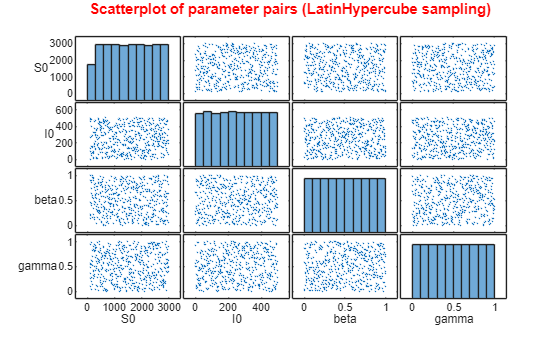

Marginal vs joint. When factors are correlated — which gsua_ia's correlation heatmap shows, and which a cost_band far above cost_data in gsua_covmetric signals — independent (marginal) draws leave the identified manifold, so the band built from them is both too wide and badly centered. Joint sampling preserves the correlation structure:

```matlab
%   Tia = gsua_ia(T, T.Estlsqc);                 % Tia.Est holds the accepted ensemble
%   Mjoint = gsua_dmatrix(Tia, 2000, 'Method','Joint', 'JointType','Bootstrap');
%
```

## 3. Uncertainty analysis — gsua_ua

gsua_ua propagates the sampled factors through the model and summarizes the spread of outputs. It automatically runs Monte-Carlo filtering (gsua_MCF) and draws it: figure(1) holds the output band, and one further figure per output shows, factor by factor, the empirical CDFs of the runs that landed below vs above the reference output.

Call syntax: Y = gsua_ua(M, T, ...).

Name–value arguments

- 'xdata' (default []) — time points to evaluate/interpolate onto; empty uses the model's own domain grid.
- 'ynom' (default []) — reference output the filtering splits runs against; empty uses the output at T.Nominal. Its length must match xdata.
- 'parallel' (default true) — evaluate the design matrix in parallel.
- 'verbose' (default true) — print the Progress: N % line.
- 'plot' (default true) — draw the figures. Set false in batch runs that call gsua_ua many times, where the figures would otherwise pile up; the returned Y is identical either way.

```matlab
Y = gsua_ua(M, T, 'xdata', xdata, 'parallel', false);
```

Progress: 100% Estimated processing time (h:m:s): 0:0:0 Remaining time (h:m:s): 0:0:0 Elapsed time (h:m:s): 0:0:0 Estimated stop time (h:m:s): 498517:33:27 Number of simulations: 500

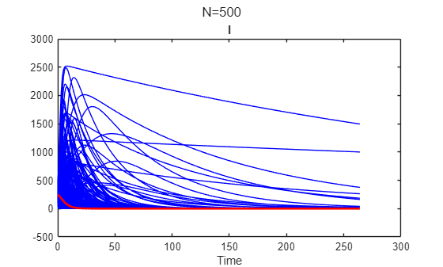

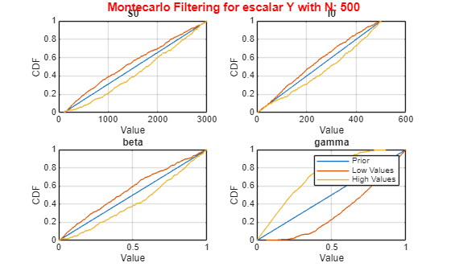

## 4. Sensitivity analysis — gsua_sa

gsua_sa estimates variance-based sensitivity indices: first-order Si (a factor's own contribution to output variance) and total STi (its contribution including interactions). It can return two extra outputs for later analysis.

Call syntax: [T,Y,J] = gsua_sa(M, T, ...) — note the order: Y is the full output matrix (as from gsua_ua) and J is its scalar MSE-vs-reference representation.

Name–value arguments

- 'SensMethod' (default 'Xiao') — estimator: 'Xiao' (newest, good for time-dependent responses, N*(Np/2+1) simulations), 'Saltelli' and 'Jansen' (same cost), 'Sobol' (classic, N*(Np+1)), 'Shapley' (Shapley effects, see below), 'OAT' (one-at-a-time, non-global, N*(Np+1)), or 'brute-force' (all combinations, N+2*Np*N^2).
- 'ynom' (default []) — reference output for index estimation; empty uses the output at T.Nominal. Index values do not depend on this choice. Its length must match xdata.
- 'xdata' (default []) — resolution [init:step:final] for the time-dependent indices; empty uses the model's domain grid.
- 'parallel' (default true) — run the simulations in parallel.
- 'verbose' (default true) — print progress.
- 'xAlpha' (default 1) — exponent in the distance-component estimator, in (0,2].
- 'bandwidth' (default 1) — bandwidth for the distance-component estimator.
- 'multiObjective' (default false) — for a model with several outputs, set true to collapse them into one depth-based objective (scalar Si/STi only). Left false, a multi-series user model — a one-argument function returning an nSeries x nSteps matrix — is analyzed per series, so Si_vec/STi_vec come back as Np x Nd x nSeries (a single output series stays the usual Np x Nd).
- 'ShapleyType' (default 'Independent') — with 'SensMethod','Shapley': 'Independent' samples the factors independently from T.Range; 'Given' uses a joint sample (the rows of M, or 'Pool') and keeps its dependence.
- 'ShapleyPerm', 'ShapleyNo', 'ShapleyNi' (defaults N, 1, 3) — permutations, outer and inner draws of the 'Independent' estimator; it costs N + ShapleyPerm*(Np-1)*ShapleyNo*ShapleyNi simulations.
- 'ShapleyK' (default 3) and 'Pool' (default []) — nearest neighbours and Np x nPool joint sample (e.g. Tia.Est) of the 'Given' estimator.

```matlab
[T,Y,J] = gsua_sa(M, T, 'SensMethod', 'Xiao', 'parallel', false);
```

Visualizing the indices. gsua_plot draws them in several forms (see also the scatter options for gsua_eval/UA results):

- gsua_plot('Pie',T,T.STi) — pie of total indices.
- gsua_plot('Bar',T,T.STi) — bar chart of total indices.
- gsua_plot('TotalSensitivityArea',T,T.STi_vec,xdata) — normalized area of the time-dependent total indices.
- gsua_plot('FractionalSensitivityArea',T,T.Si_vec,xdata) — area of the time-dependent first-order indices.
- gsua_plot('ScatterOutput',T,J,M,xdata) — scatter of the scalar output against each factor.
- After 'SensMethod','Shapley' the indices are in T.Sh / T.Sh_vec: gsua_plot('Pie',T,T.Sh), gsua_plot('FractionalSensitivityArea',T,T.Sh_vec,xdata).

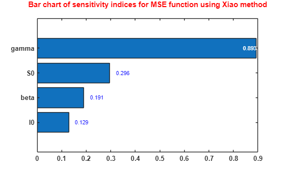

```matlab
clf
gsua_plot('Bar', T, T.STi)
```

Interpreting the indices. STi is the key measure of factor relevance. The sum of STi is always >= 1 and the sum of Si always <= 1; if either equals 1 so does the other, and the model is purely additive. Two diagnostics, both from Lizarralde-Bejarano, Rojas-Díaz et al. (2020, PLOS ONE): (1) estimator reliability — the Saltelli/Xiao estimators can return negative Si at finite N, although true first-order indices are non-negative, so gauge reliability with the ratio sum(Si)/sum(|Si|): it is 1 when no spurious negatives appear and falls below 1 as negative-index noise grows, so a value well under 1 means N is too small — raise it; (2) additivity — once that ratio is near 1, judge interactions from sum(Si) itself: as sum(Si) → 1 (equivalently sum(Si) ≈ sum(STi)) interactions are negligible and a local or analytical SA suffices. Neither quantity has a published numeric cutoff; any specific threshold is a user judgment, not a toolbox rule.

Indices outside [0,1]. Sensitivity indices lie in [0,1] by definition, but their Monte Carlo estimates do not: with a small N an estimated STi can exceed 1 (and an Si can be negative). That is sampling noise of the estimator, not an implementation error, and the toolbox deliberately does not clip it — clipping would hide that N is too small. On the Ishigami test function at N = 64, 25% of 'Saltelli' runs, 9% of 'Sobol' runs and 6% of 'Jansen' runs gave some STi > 1, against none for the default 'Xiao'; all vanish as N grows. The cure is a larger N, judged with the ratio above.

What each estimator measures. 'Sobol' and 'Jansen' estimate the variance-based (Sobol') indices of the output. 'Xiao' (Xiao, Lu & Wang 2018) is a distance-components estimator, STi = E|YA-YABi|^a / E|YA-YB|^a with a = 'xAlpha': with 'xAlpha',2 it reproduces the Jansen (variance-based) index, while the default 1 gives a moment-independent, distribution-based index — more robust, but it can rank factors differently from Sobol'. 'Saltelli' scores the squared departure from the nominal trajectory, (Y-ynom).^2, rather than Y itself, so its Si_vec/STi_vec answer a different question from Sobol'/Jansen. For every method the scalar Si/STi are indices of the cost J.

Shapley effects. 'SensMethod','Shapley' shares the output variance among the factors, splitting every interaction fairly between the factors involved (Owen 2014; Song, Nelson & Staum 2016). The effects sum to 1, satisfy Si <= Sh_i <= STi for independent factors, and — unlike Sobol' indices — stay meaningful when the factors are dependent, such as structurally coupled parameters (R0 = beta*S0/gamma). The 'Independent' estimator samples the factors from their ranges; the 'Given' estimator (Broto, Bachoc & Depecker 2020) works on a joint sample and keeps its dependence. With an accepted-estimate ensemble the second answers how the output variance is shared inside the identified region:

Mj = gsua_dmatrix(Tia, 2000, 'Method','Joint', 'JointType','SmoothBootstrap'); then Tsh = gsua_sa(Mj, Tia, 'SensMethod','Shapley', 'ShapleyType','Given'); — or pass the ensemble itself with 'Pool', Tia.Est. Use a few hundred distinct vectors or more: repeated vectors are dropped, so the default 'Bootstrap' joint sampling (which only repeats pool vectors) adds nothing beyond the pool itself.

## 5. Parameter estimation — gsua_pe

gsua_pe fits the model to data by multistart optimization, returning the table with the estimates attached (T.Est<solver>, e.g. T.Estlsqc) and the per-run cost res. It also records, aligned to the sorted results, the initial point actually used for each run in T.IP<solver> and the number of silent restarts from a random point in the Retries<solver> custom property, so the retry behaviour is traceable rather than hidden.

Call syntax: [T,res] = gsua_pe(T, xdata, ydata, ...).

Name–value arguments

- 'N' (default 1) — number of estimation runs (multistart restarts from different points).
- 'solver' (default 'lsqc') — optimizer: 'lsqc' (lsqcurvefit), 'lsqn' (lsqnonlin), 'fmincon', 'ga', 'particle' (particleswarm), 'psearch' (patternsearch), 'surrogate', or 'annealing' (simulannealbnd).
- 'opt' (default []) — an optimoptions object for the chosen optimizer (the optimizer name must match). For the gradient solvers (fmincon/lsqc/lsqn), if you leave TypicalX unset, gsua_pe fills it with the nominal factor magnitudes (max(abs(T.Nominal),eps)), so factors spanning many orders of magnitude are scaled sensibly by the finite differences.
- 'Multistart' (default 1) — number of estimations per cycle using MATLAB's MultiStart (lsqcurvefit only).
- 'ipoint' (default []) — explicit initial points, with N rows and one column per free factor, instead of random starts.
- 'margin' (default 0) and 'alpha' (default 2) — switch the objective from plain least squares to the correlation-penalized multi-objective cost (gsua_costf), which is what you want when one model must match several signals at once. gsua_pe records both on the table so gsua_noisefloor (section 7) recovers them automatically. The value you pass is a relative residual band: with a good-shape fit, cost < 1 means the residual RMS is within that fraction of the data RMS (0.3 ≈ 30%). It is used internally as m+1 and, because the regulator does not depend on the parameters, it only rescales the cost — it does not move the optimum, only what cost < 1 and the noise-floor threshold mean. Only the cost-function solvers (ga, particle, psearch, surrogate, annealing, fmincon) use this cost and record margin/alpha on the table; lsqc/lsqn ignore margin and their res is the optimizer's own sum of squares.
- 'A', 'B', 'Aeq', 'Beq', 'nonlcon' (default []) — linear (A*x<=B, Aeq*x=Beq) and nonlinear constraints passed through to the optimizer.
- 'Show' (default 'off') — 'on' plots the optimizer results; 'on2' also calls gsua_ia.
- 'save' (default false) — if true, writes Estimations.mat to the current folder after each run as a crash-resume checkpoint, overwriting any existing file of that name. (It defaulted to true before v1.15.)
- 'timer' (default true) — print per-estimation progress.

```matlab
opt = optimoptions('lsqcurvefit', 'Display', 'off');
[T,res] = gsua_pe(T, xdata, yexp, 'solver', 'lsqc', 'N', 10, 'opt', opt, 'timer', false);
T
```

T = 4×8 table

|  | Range 1 | Range 2 | Nominal | Si | STi | STi_vec 1 | STi_vec 2 | STi_vec 3 | STi_vec 4 | STi_vec 5 | STi_vec 6 | STi_vec 7 | STi_vec 8 | STi_vec 9 | STi_vec 10 | STi_vec 11 | STi_vec 12 | STi_vec 13 | STi_vec 14 | STi_vec 15 | STi_vec 16 | STi_vec 17 | STi_vec 18 | STi_vec 19 | STi_vec 20 | STi_vec 21 | STi_vec 22 | STi_vec 23 | STi_vec 24 | … |
| --- | --- | --- | --- | --- | --- | --- | --- | --- | --- | --- | --- | --- | --- | --- | --- | --- | --- | --- | --- | --- | --- | --- | --- | --- | --- | --- | --- | --- | --- | --- |
| 1 S0 | 100 | 3000 | 1550 | -0.0738 | 0.2962 | 0 | 0.1183 | 0.2007 | 0.2528 | 0.2851 | 0.3101 | 0.3291 | 0.3430 | 0.3507 | 0.3536 | 0.3527 | 0.3496 | 0.3459 | 0.3424 | 0.3385 | 0.3354 | 0.3328 | 0.3307 | 0.3291 | 0.3280 | 0.3272 | 0.3266 | 0.3262 | 0.3259 | … |
| 2 I0 | 1 | 500 | 250.5000 | 0.0362 | 0.1289 | 1 | 0.8900 | 0.6561 | 0.4921 | 0.3761 | 0.2959 | 0.2373 | 0.1988 | 0.1777 | 0.1639 | 0.1565 | 0.1511 | 0.1442 | 0.1373 | 0.1343 | 0.1297 | 0.1246 | 0.1191 | 0.1187 | 0.1185 | 0.1201 | 0.1208 | 0.1210 | 0.1239 | … |
| 3 beta | 0 | 1 | 0.5000 | 0.0042 | 0.1906 | 0 | 0.3266 | 0.4765 | 0.5261 | 0.5230 | 0.5018 | 0.4708 | 0.4367 | 0.4027 | 0.3731 | 0.3475 | 0.3275 | 0.3097 | 0.2957 | 0.2843 | 0.2742 | 0.2648 | 0.2579 | 0.2532 | 0.2499 | 0.2463 | 0.2438 | 0.2406 | 0.2367 | … |
| 4 gamma | 0 | 1 | 0.5000 | 0.5963 | 0.8929 | 0 | 0.4180 | 0.6224 | 0.7178 | 0.7632 | 0.7945 | 0.8136 | 0.8243 | 0.8277 | 0.8287 | 0.8291 | 0.8300 | 0.8322 | 0.8356 | 0.8376 | 0.8409 | 0.8449 | 0.8490 | 0.8536 | 0.8589 | 0.8641 | 0.8696 | 0.8751 | 0.8804 | … |

## 5.1 Practical identifiability — gsua_ia and gsua_dia

gsua_ia turns a pool of repeated estimates into identifiability diagnostics: per-factor CDFs and boxplots, a factor-correlation heatmap, and an identifiability index. It replaces T.Range with a distribution-free confidence interval of the median (gsua_medianCI), sets T.Nominal to the median estimate, T.index to the per-factor index (0 = well identified, 1 = poorly identified), and T.Est to the estimates actually used. gsua_dia computes the same statistics without drawing any figures — use it in scripted pipelines.

Call syntax: [T,clusterInfo] = gsua_ia(T, T_est, correction, outlier, show, cluster, maxK, silThreshold, ...). The first arguments are positional:

- correction (default false) — clip the new range back to the original T.Range when it would otherwise widen.
- outlier (default false) — remove multivariate outliers before computing statistics. Note the bundled detector is aggressive on clean, tightly clustered data; inspect T.Est if results surprise you.
- show (default false) — plot the identifiability-index scatter, correlation graph, and (if cluster is true) the clustering diagnostics.
- cluster (default false) — run spectral clustering to detect multiple global minima (distinct basins the optimizer landed in) rather than assuming one. Requires Statistics and Machine Learning Toolbox.
- maxK (default 5) — largest cluster count tested.
- silThreshold (default 0.5) — minimum mean silhouette score to accept a multi-cluster split over a single basin.

Name–value arguments (fit-quality filtering, shared with gsua_costcutoff):

- 'cost' (default []) — the res output of gsua_pe, one entry per column of T_est; screens out runs that converged badly before any statistic is computed.
- 'CostMethod' (default 'rtol') — 'rtol' (keep cost <= min*(1+CostRtol)+CostAtol) or 'gap' (cut at the largest jump in the sorted costs).
- 'CostRtol' (default 0.1), 'CostAtol' (default 1e-8), 'CostGapRatio' (default 3), 'MinKeep' (default 3) — tolerances for the two methods and a floor on how many runs survive.
- 'IndexMethod' (default 'spread') — how the index measures interval width. 'spread' uses the estimates' 2.5–97.5 percentile dispersion over the original range, so a factor scattered across its whole prior is not called identified even when its median is well pinned; 'ci' is the legacy median-CI width, which shrinks with sample size.
- 'truth' (default []), 'xdata'/'ydata' (default []) — with show, 'truth' (an Np x 1 reference vector) is marked on the CDFs, boxplots and per-cluster scatter, and 'xdata'+'ydata' draw each cluster's curve against the observed data.

```matlab
T_newRange = gsua_ia(T, T.Estlsqc)
```

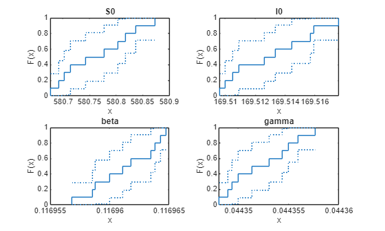

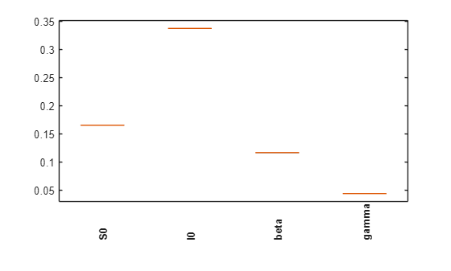

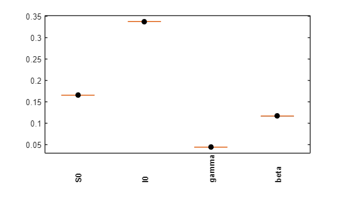

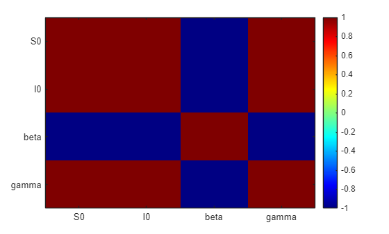

T_newRange = 4×10 table

|  | Range 1 | Range 2 | Nominal | Si | STi | STi_vec 1 | STi_vec 2 | STi_vec 3 | STi_vec 4 | STi_vec 5 | STi_vec 6 | STi_vec 7 | STi_vec 8 | STi_vec 9 | STi_vec 10 | STi_vec 11 | STi_vec 12 | STi_vec 13 | STi_vec 14 | STi_vec 15 | STi_vec 16 | STi_vec 17 | STi_vec 18 | STi_vec 19 | STi_vec 20 | STi_vec 21 | STi_vec 22 | STi_vec 23 | STi_vec 24 | … |
| --- | --- | --- | --- | --- | --- | --- | --- | --- | --- | --- | --- | --- | --- | --- | --- | --- | --- | --- | --- | --- | --- | --- | --- | --- | --- | --- | --- | --- | --- | --- |
| 1 S0 | 580.7019 | 580.8181 | 580.7607 | -0.0738 | 0.2962 | 0 | 0.1183 | 0.2007 | 0.2528 | 0.2851 | 0.3101 | 0.3291 | 0.3430 | 0.3507 | 0.3536 | 0.3527 | 0.3496 | 0.3459 | 0.3424 | 0.3385 | 0.3354 | 0.3328 | 0.3307 | 0.3291 | 0.3280 | 0.3272 | 0.3266 | 0.3262 | 0.3259 | … |
| 2 I0 | 169.5105 | 169.5157 | 169.5130 | 0.0362 | 0.1289 | 1 | 0.8900 | 0.6561 | 0.4921 | 0.3761 | 0.2959 | 0.2373 | 0.1988 | 0.1777 | 0.1639 | 0.1565 | 0.1511 | 0.1442 | 0.1373 | 0.1343 | 0.1297 | 0.1246 | 0.1191 | 0.1187 | 0.1185 | 0.1201 | 0.1208 | 0.1210 | 0.1239 | … |
| 3 beta | 0.1170 | 0.1170 | 0.1170 | 0.0042 | 0.1906 | 0 | 0.3266 | 0.4765 | 0.5261 | 0.5230 | 0.5018 | 0.4708 | 0.4367 | 0.4027 | 0.3731 | 0.3475 | 0.3275 | 0.3097 | 0.2957 | 0.2843 | 0.2742 | 0.2648 | 0.2579 | 0.2532 | 0.2499 | 0.2463 | 0.2438 | 0.2406 | 0.2367 | … |
| 4 gamma | 0.0443 | 0.0444 | 0.0444 | 0.5963 | 0.8929 | 0 | 0.4180 | 0.6224 | 0.7178 | 0.7632 | 0.7945 | 0.8136 | 0.8243 | 0.8277 | 0.8287 | 0.8291 | 0.8300 | 0.8322 | 0.8356 | 0.8376 | 0.8409 | 0.8449 | 0.8490 | 0.8536 | 0.8589 | 0.8641 | 0.8696 | 0.8751 | 0.8804 | … |

When cluster is true and a genuine split is found, every statistic in T reflects the dominant (largest) cluster only — pooling separated basins into one interval is not meaningful — while clusterInfo describes every basin. Besides NumClusters, Centers (one candidate global minimum per basin), ClusterSize, Silhouette and Dominant, it carries per-cluster cells Range{c}/Index{c}/Est{c}/Median{c} (each computed like the dominant), the cluster-count diagnostic SilhouetteByK/SilhouetteK, and — over the original T_est columns — the fit-quality survivor mask Kept and the labels Idx (NaN for cost-dropped runs). gsua_clustersummary(T, clusterInfo) turns it into a per-cluster, per-factor table with an identifiability verdict:

```matlab
%   [Tia,clusterInfo] = gsua_ia(T, T.Estlsqc, false, false, true, true, 'cost', res);
%   clusterInfo.NumClusters   % > 1 means distinct basins were found
%   clusterInfo.Centers       % one candidate global minimum per basin
%   clusterInfo.Range{2}      % cluster 2's own confidence interval
%   S = gsua_clustersummary(Tia, clusterInfo)   % per-cluster, per-factor verdict table
%
```

## 5.2 Parametric bootstrap of parameter uncertainty — gsua_bootstrap

Re-fitting the same data from many starting points (multistart) explores the cost function but collapses to one optimum — it does not measure how much the data noise moves each estimate. gsua_bootstrap does: from the best fit it generates B synthetic datasets under the data's own observation-noise model (the same 'poisson'/'quasipoisson'/'nbglobal' models as gsua_noisefloor, with cumulative-series support), re-fits each with gsua_pe, and returns the ensemble ready to pass to gsua_ia. Feed gsua_ia this bootstrap ensemble, not the raw multistart pool, for honest uncertainty intervals and correlations.

Call syntax: [Est,costs] = gsua_bootstrap(T, xdata, ydata, Est0, res, ...), where Est0/res are a pool (e.g. T.Estfmincon, res) whose best member seeds the noise model.

- 'B' (default 200) — number of synthetic datasets / refits.
- 'solver' (default 'fmincon'), 'N' (default 20), 'margin'/'alpha' (default recovered from T) — the gsua_pe options used per replica.
- 'noise' (default 'quasipoisson') — the observation-noise model. A single name applies to every output row (count models 'poisson'/'quasipoisson'/'nbglobal', which assume integer counts); for a joint fit mixing count rows and 0–1 fraction rows, pass a per-row cellstr adding 'gaussian' (additive, std from that row's residuals) or 'none' (no perturbation), e.g. {'quasipoisson','none'}, so count noise — and zeros — are never drawn on a fraction row.
- 'cumulative', 'seed', 'parallel' (default false) — per-row cumulative flags, RNG seed, and whether to parallelize the refits.

```matlab
%   [T,res] = gsua_pe(T, xdata, ydata, 'solver','fmincon', 'margin',0.3, 'N',200);
%   Eb = gsua_bootstrap(T, xdata, ydata, T.Estfmincon, res, 'B',200, 'seed',1);
%   [T,ci] = gsua_ia(T, Eb, false, false, true, true);   % honest uncertainty from the bootstrap
%
```

## 6. Uncertainty-interval calculus — gsua_oatr and gsua_csb

These size a confidence interval around an estimate by sampling. gsua_oatr expands each factor's range one at a time around the objective output stored in T.Nominal; gsua_csb then estimates the confidence subcontour box by iterated sampling. gsua_oatr2 is a second-generation one-at-a-time refinement.

gsua_oatr call syntax: T = gsua_oatr(T, ...).

- 'lim' (default 0.3) — distance limit for range expansion.
- 'parallel' (default false) — parallelize the range calculus.
- 'correct' (default false) — clip expansions to the original range.
- 'show' (default false) — plot the iterations.
- 'titerlimit' (default inf) — cap on total iterations (gsua_oatr only).

gsua_csb call syntax: [T,New_range,J_test,Y_test,sup] = gsua_csb(T, N, ...), where N is samples per cycle. Do not run gsua_csb inside a Live Script — run it in the command window.

- 'reps' (default 100) — number of cycles.
- 'stop' (default 0.95) — confidence level of the interval.
- 'lim' (default 0.3) — distance criterion.
- 'select' (default 0.5) — selection criterion.
- 'switch' (default 0.75) — cut criterion. (Older help called this 'recort'; the actual argument is 'switch'.)
- 'ynom' (default []) — a new objective output.
- 'correct' (default true), 'parallel' (default false), 'show' (default false) — clip to bounds, parallelize, plot.
- Advanced (rarely needed): 'protect' (logical, default false) guards the sampling; 'stretch' (default 3) caps the self-recursion depth; 'breaking' (default 1) is the internal recursion counter — leave it at the default.

```matlab
T.Nominal = [1000 200 0.1 0.06]';
T_oat = gsua_oatr(T);
```

Expansion-reduction Method OAT is being launched ------------------------------------ Calculus of gamma Starting Range for gamma Done! Initial range of gamma(4)--> 0 1 Actual range --> 0.049687 0.075055 Calculus of beta Starting Range for beta Done! Initial range of beta(3)--> 0 1 Actual range --> 0.068594 0.13938 Calculus of I0 Starting

Warning: Failure at t=4.969935e+01. Unable to meet integration tolerances without reducing the step size below the smallest value allowed (1.136868e-13) at time t.

Warning: Attempting to evaluate the solution outside the interval [0.000000e+00, 4.969935e+01] where it is defined.

Range for I0 Done! Initial range of I0(2)--> 1 500 Actual range --> -38.8 313.2031 Calculus of S0 Starting Range for S0 Done! Initial range of S0(1)--> 100 3000 Actual range --> 571.79688 1456.25

```matlab
%   T_csb = gsua_csb(T_oat, 100)   % run in the command window, not here
%
```

## 7. Fit quality, acceptance, and confidence intervals

Sections 5 and 6 give an estimate and a range. The functions here answer what comes next: was the fit good enough to believe, which multistart runs to keep, how wide the acceptance band should be, and what the confidence interval of each factor is once the others are free to move.

## 7.1 Band coverage and tightness — gsua_covmetric

gsua_covmetric scores a Monte-Carlo band against the data with two numbers on the same normalized scale (below 1 = within tolerance): cost_data, the distance from the band median to the data (accuracy), and cost_band, the distance between the band edges (precision, independent of the data). A cost_band far larger than cost_data is the signature of factor confounding — the band is wide because the sampled factors are inconsistent with each other, which is exactly what the joint sampling in section 2 fixes.

Call syntax: [cost_data,cost_band,P5,P50,P95] = gsua_covmetric(Y, ydata, ...).

- 'margin' (default 0.1) — relative tolerance for the shared normalization (values <1 are read as a fraction and converted to 1+margin).
- 'alpha' (default 2) — exponent on each per-signal cost term.
- 'plevels' (default [5 95]) — [low high] percentile levels defining the band.

```matlab
%   M = gsua_dmatrix(T,2000);
%   Y = gsua_ua(M,T,'xdata',xdata);
%   [cost_data,cost_band] = gsua_covmetric(Y,yexp,'margin',0.1);
%
```

## 7.2 Which runs to keep — gsua_costcutoff

A multistart run that converged to a much worse cost than the best one contributes essentially arbitrary factor values; left in the pool it can make a well-identified factor look poorly identified. gsua_costcutoff decides which runs to keep. It is the filter gsua_ia/gsua_dia apply through their 'cost' argument, exposed on its own.

Call syntax: keep = gsua_costcutoff(cost, method, rtol, atol, gapRatio, minKeep) — all six arguments are positional and required (the gsua_ia defaults are 'rtol', 0.1, 1e-8, 3, 3). method is 'rtol' (keep cost <= min*(1+rtol)+atol) or 'gap' (cut at the largest jump in the sorted log-costs, only if it is at least gapRatio times the median gap). minKeep guarantees the pool is never emptied.

```matlab
%   keep = gsua_costcutoff(res,'rtol',0.1,1e-8,3,3);
%   Est_kept = T.Estlsqc(:,keep);
%
```

## 7.3 A data-calibrated acceptance threshold — gsua_noisefloor

The common rule res < 1.5*res(1) is scale-dependent: it asks how close a run is to the best run, not whether it is statistically distinguishable from the truth, so it tightens as the fit improves and can reject curves that describe the data perfectly well. gsua_noisefloor replaces it with a parametric bootstrap: it simulates the best fit, estimates an observation-noise model from that fit's residuals, generates synthetic datasets under that noise, and scores the true model against each with the same cost gsua_pe minimized. The upper quantile of that distribution is a data-calibrated acceptance threshold. Because gsua_pe records the margin and alpha it used on the table, gsua_noisefloor recovers them automatically — but only the cost-function solvers (fmincon, ga, particle, psearch, surrogate, annealing) record them; with lsqc/lsqn, which ignore margin, pass 'margin'/'alpha' to gsua_noisefloor explicitly, or it errors with NoMarginAlpha.

Call syntax: out = gsua_noisefloor(T, xdata, ydata, Est, res, ...).

- 'B' (default 2000) — bootstrap sample size.
- 'noise' (default 'quasipoisson') — noise model: 'poisson' (usually far too tight for real data), 'quasipoisson' (recommended; variance phi*mu), or 'nbglobal' (single pooled negative-binomial k, report as a bound only). out.byModel reports all three regardless, as a sanity check.
- 'quantile' (default 0.95) — upper quantile of the bootstrap cost distribution that defines the threshold.
- 'cumulative' (default all false) — one logical flag per output row; a cumulative series has its noise estimated on the first-differenced (incident) series and re-accumulated.
- 'seed' (default none) — seed for reproducible draws; the caller's global RNG state is always restored on return.
- 'margin', 'alpha' (default recovered from the table) — override the values gsua_pe scored with, in gsua_pe's own convention.
- 'Show' (default false) — plot the sorted pool costs (log scale) with the threshold and accepted/rejected runs marked, and the bootstrap cost distribution with the chosen quantile.

Key outputs: out.threshold (the cutoff on the res scale), out.accepted (logical res < threshold), and out.byModel (all three noise models). If the best fit itself exceeds the floor, a warning fires — the model is rejected as a description of the data at that quantile.

```matlab
%   [T,res] = gsua_pe(T,xdata,yexp,'solver','fmincon','N',50,'margin',0.1);
%   out = gsua_noisefloor(T,xdata,yexp,T.Estfmincon,res);   % fmincon records Margin; noisefloor recovers it
%   Tia = gsua_ia(T, T.Estfmincon(:,out.accepted));
%
```

## 7.4 Profile-likelihood confidence intervals — gsua_likelihood

gsua_likelihood scans each factor across a range while re-estimating all the others at every step, and reports the interval where the profiled cost stays below a likelihood-ratio threshold. It is slower than the distribution-free interval gsua_ia reports, but because it re-fits the remaining factors it accounts for their trade-offs — the better choice precisely when factors are correlated.

Call syntax (all arguments positional): Tfinal = gsua_likelihood(T, xdata, ydata, alpha, step, margin, tolerance1, tolerance2, limit, reps, show, parallel, saver, pars, verbose). Here alpha is the confidence level (e.g. 0.95), step the initial relative step, margin the relative standard deviation in the Gaussian likelihood weighting, tolerance1/tolerance2 the bisection stopping tolerances, limit the iteration cap per bound, reps the estimations per inner gsua_pe call, and pars the factor indices to profile ([] = all). verbose (default true) is optional. Note (v1.18): margin is now the raw relative standard deviation (0.08 = 8% noise), unified with gsua_pe/gsua_costf. It used to be offset by one (you passed 1.08 for 8%); a value >= 1 now raises a MarginConvention warning.

```matlab
%   Tci = gsua_likelihood(T,xdata,yexp,0.95,0.05,0.08,0.01,0.01,15,10,false,false,false,[]);
%
```

## 8. Supporting functions

The functions above are the main workflow. These fill it in:

- gsua_dia — the identifiability statistics of gsua_ia without the plots (positional args outlier, cluster, maxK, silThreshold, same 'cost'/'CostMethod'/... name–value set).
- gsua_oatr2 — second-generation one-at-a-time range refinement ('lim' 0.3, 'parallel', 'correct', 'show').
- gsua_medianCI — distribution-free confidence interval of the median, [lo,hi] = gsua_medianCI(X, alpha) with alpha default 0.05; this is what gsua_ia uses to build T.Range.
- gsua_depth — generalized band depth, [depth,idx] = gsua_depth(x, parallel), for ranking curves by centrality; gsua_sa uses it to pick a reference output when no 'ynom' is given.
- gsua_MCF — Monte-Carlo filtering on its own, [Jsup,Jinf] = gsua_MCF(T, M, Y, y_exp, tIn, tOut), outside of gsua_ua.
- gsua_userdefined — build T straight from a user function, bypassing gsua_dataprep (same name–value arguments; see the appendix).
- gsua_fullpars — reinsert fixed factors into a free-parameter vector: [full,names] = gsua_fullpars(T, freeValues). A fixed factor drops out of T, so estimates carry only the free factors; this rebuilds the complete ordered vector (with the pinned values put back) for computing derived quantities or comparing against a full ground truth.
- gsua_deval and gsua_pardeval — single and batched model evaluation used internally; gsua_pardeval(M,T,xdata,parallel,init,verbose).
- gsua_costf, gsua_rcostf, gsua_costfMulti, gsua_likecost — the cost functions gsua_pe minimizes.

## 9. Python port

A Python port is maintained in the python folder (package gsua_csb). It mirrors these functions under idiomatic names, keeping gsua_-prefixed aliases for cross-reference: design_matrix/gsua_dmatrix, parameter_estimation/gsua_pe, identifiability_analysis/gsua_ia, noise_floor/gsua_noisefloor, and so on. Simulink models are MATLAB-only; symbolic ODE and user-defined models are both supported there. See python/USERGUIDE.md for its guide and python/README.md for what is and is not ported.

## Appendix A — Simulink models

Prepare a Simulink model as described in the Simulink setup guide, then:

[T,tout] = gsua_dataprep(model, Ranges, Parameter_names) — model is the model file name, Ranges an Np x 2 array (or a cell array, see 'rMethod'), and Parameter_names a cell/string array of factor names. Each factor must be assigned in the model workspace as a reference to a named variable (the toolbox matches factors by name); give a factor a constant value instead to exclude it. At present a Simulink model exposes a single output — connect an output block to the objective signal and terminators elsewhere.

Name–value arguments

- 'rMethod' (default 'range') — how Ranges is read: 'range' {lower, upper}, 'std' {nominal, distance}, 'percent' {nominal, percent}, or 'normal' {nominal, std}. A third column in a cell Ranges sets a per-factor method (do not mix in 'normal'). The normal method also shapes how gsua_dmatrix draws samples.
- 'nominal' (default midpoint of Ranges) — an explicit nominal factor family.
- 'modelkind' (default 'Dynamic') — set 'Static' for static models (initial time = final time = 0).
- 'Step' (default []) — a fixed solver step magnitude.

```matlab
%   model = 'predatorprey';
%   ParIn = {'beta','delta','ro','P0'};
%   Ranges = [0.4 0.6; 0.4 0.6; 2.2 2.8; 2.7 3.2];
%   [T,time] = gsua_dataprep(model, Ranges, ParIn);
%
```

## Appendix B — Symbolic ODE models

Build the system with the Symbolic Math Toolbox, choose an order for the state variables, then: [T,solver] = gsua_dataprep(odes, vars, domain, modelName). odes is the equation array, vars the state-variable array, domain a 1 x 2 time span, and modelName the name of the model file the function writes for later simulations. If your system is in y^(n) = f(...) form, reduce it first with reduceDifferentialOrder.

Name–value arguments

- 'range' / 'rMethod' (default 'range') — provide the factor ranges and how they are read ('range', 'std', 'percent', 'normal'), as for Simulink. Fix a factor with a degenerate range.
- 'nominal' (default midpoint) — explicit nominal factor family.
- 'output' (default 1:model_order) — which state(s) to expose (one output for SA and CSB).
- 'solver' (default 'ode45') — 'ode45' (adaptive) or 'ode4' (fixed step; add a third column to domain for the step).
- 'opt' (default none) — an odeset options struct (for ode4, only NonNegative is supported).

```matlab
%   syms S(t) I(t) R(t) beta gamma
%   P = S+I+R;
%   odes = [diff(S)==-S*I*beta/P; diff(I)==S*I*beta/P-gamma*I; diff(R)==gamma*I];
%   vars = [R S I];
%   Ranges = [0 0; 100 3000; 1 500; 0 1; 0 1];
%   [T,solver] = gsua_dataprep(odes, vars, [0 264], 'SIR', 'range', Ranges);
%
```

## Appendix C — User-defined functions

Store the model as a .m file. A time-dependent function has the form sol = user_function(factors, domain, opt) — three inputs always (declare opt even if unused, as ~): a two-input handle is accepted by gsua_dataprep but fails at evaluation, because a user model is built as Kind 5 and called as fun(factors, domain, opt). factors arrives as a column vector, domain is [t0 tf], and it returns a struct with sol.x (time, 1 x Nt, from t0 to tf) and sol.y (outputs, nOutputs x Nt, one row per out_names entry). For a continuous model, integrate with ode45 inside the function and return deval on a fine, regular grid — do not return the solver's raw adaptive steps: gsua_eval interpolates sol.y linearly, so the crude steps degrade accuracy (the toolbox still normalizes either ode45 output orientation, but relying on the raw steps is the classic precision bug — see module 0). A time-free function has the form out = user_function(factors) and returns a numeric array (vectorized) or a scalar; if its output is a vector, treat it as time-dependent and ignore the domain argument inside the function. If it returns a matrix (nSeries x nSteps, several output series at once), the whole workflow — gsua_ua, gsua_sa, gsua_pe, gsua_dia — now handles it per series without a scalar adapter; the output shape is detected from the nominal run (or set it explicitly with 'output_size').

Prepare it with [T,solver] = gsua_dataprep(func, Ranges, 'domain', domain) (func is the file name as a char; the second output is the solver handle, not a solution). gsua_userdefined does the same directly.

Name–value arguments

- 'domain' (default 1) — time span passed to the function when it takes 2+ inputs.
- 'rMethod' (default 'range') — read Ranges as 'range', 'std', 'percent', or 'normal'. Fix a factor with a degenerate range.
- 'nominal' (default midpoint of Ranges) — explicit nominal factor family.
- 'output' (default all) — indices of the function's outputs to expose.
- 'names' (default auto 1..Np) — factor names (cellstr, string array, or char), shown on plots; TeX and LaTeX are both rendered.
- 'out_names' (default {'out'}) — output names, shown on plots (auto-numbered out1..outN for a matrix-returning function left at the default).
- 'output_size' (default []) — [nSeries nSteps] for a matrix-returning one-argument function, to skip the automatic shape detection (useful when evaluating the nominal is costly or unsafe at build time).
- 'vectorized' (default false) — set true if the function accepts a batch of factor sets at once (single-input functions only).
- 'opt' (default struct('action',1)) — anything passed through to a three-input function's third argument.

```matlab
%   func = 'user_dependent';
%   ranges = [0.1 0.3; 10 14];
%   [T,solver] = gsua_dataprep(func, ranges, 'domain', [0 25], 'names', {'\tau','\lambda'});
%
```